# One sample T-toets

Irene van der Staaij & Megiel Kerkhoven

7/26/2019

## Gebruik

Gebruik de *One sample t-toets* bij een hypothese over het gemiddelde in één groep, bijvoorbeeld gemiddeld tentamencijfer.[^1].

## Voorbeeld uit het onderwijs

De opleidingsdirecteur van de opleiding Economie wil weten of het gemiddelde eindexamencijfer voor Wiskunde A van haar VWO studenten lager is dan het landelijke gemiddelde, zodat zij kan bepalen of het zinnig is om een zomercursus statistiek te starten.

H<sub>0</sub>: Het gemiddelde cijfer voor wiskunde A van VWO studenten bij de opleiding Economie is een zes, µ = 6.

HA: Het gemiddelde cijfer voor wiskunde A van VWO studenten bij de opleiding Economie is anders dan een zes, µ ≠ 6.

## Assumpties

### Normaliteit

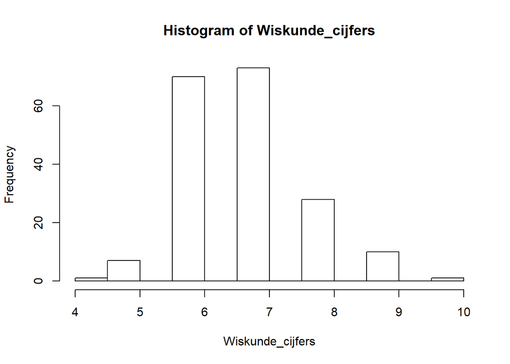

```r
hist(Wiskunde_cijfers)
```

## Uitvoering in R

```r
set.seed(100)
x <- rnorm(50, mean = 10, sd = 0.5)
t.test(x, mu = 10) # testing if mean of x could be
```

```
##
##  One Sample t-test
##
## data:  x
## t = 0.70372, df = 49, p-value = 0.4849
## alternative hypothesis: true mean is not equal to 10
## 95 percent confidence interval:
##   9.924374 10.157135
## sample estimates:
## mean of x
##  10.04075
```

## Toelichting op de output

df = n -1 p-value is flink boven de 0.05, dus niet significant, sterker nog hij is bijna 0.5 dus het is net als kop of munt gooien.

## Verder lezen

Open Intro Statistics Third Edition

## Achtergrond info

De t-toets wordt ingezet wanneer de data numeriek en (gedeeltelijk) normaal verdeeld is, maar de keuze welke t-toets men kiest is afhankelijk van het aantal groepen wat je bekijkt en de relatie tussen de twee groepen.

[^1]: amc-wiki.
[^2]: https://wiki.uva.nl/methodologiewinkel/index.php/Normaliteit
[^3]: https://statistics.laerd.com/spss-tutorials/testing-for-normality-using-spss-statistics.php
[^4]: http://r-statistics.co/Statistical-Tests-in-R.html